# MATH-156 - Week 3 - Finding Associations

Last time we looked at a few different case studies involving categorical variables. In doing so, we established the following general procedure for approaching a new dataset:

1. Identify the cases and variables
2. Look the distributions of each variable
3. Look at the relationship of interest between two variables
4. Check for confounding variables that might affect that relationship
5. Stratify the data if necessary

Today we will approach things from a slightly different perspective. Instead of beginning with a specific comparison in mind, we’ll instead use data exploration to help us identify potentially interesting relationships. This will require us to practice relating many different types of variables.

**Directions**:

- For this activity, I’d like you record your responses in a word doc or a shared google doc
- On certain questions you will be asked to include screenshots
  - On Windows PCs, you can use the snipping tool app (start typing “snipping tool” into the Windows search bar)
  - On Mac PCs, there are several ways to take a screenshot: https://www.cleverfiles.com/howto/snipping-tool-mac.html
- On Canvas you may submit either your answer document itself, or a link to the google doc (make sure I have permission to view it)
  - The score you receive will be primarily based upon effort, and it’s okay if you don’t finish. That said, these questions are excellent practice for the upcoming exam!

## Case Study #1 - College Scorecard Data

The College Scorecard is a government run database that stores institutional level data on all accredited colleges and universities in the United States. A new version of the data is published yearly, and contains over 400 variables. This lab will use a simplified dataset from the 2019-2020 academic year.

### Data Dictionary

The [College19 Dataset](https://remiller1450.github.io/data/Colleges2019.csv) is a reduced version of the 2019-2020 College Scorecard data that includes fewer variables and is filtered to include only primarily undergraduate institutions with at least 400 enrolled students. It contains the following variables:

- **Name** - Name of the institution
- **City** - City where the institution is located
- **State** - State where the institution is located
- **Enrollment** - Number of full-time enrolled students
- **Private** - Binary indicator distinguishing public and private institutions
- **Region** - Geographic region
- **Adm_Rate** - Admissions rate, the proportion of applications who are admitted
- **ACT_median** - Median composite ACT score of enrolled students
- **ACT_Q1** - 25th percentile composite ACT score of enrolled students
- **ACT_Q3** - 75th percentile composite ACT score of enrolled students
- **Cost** - Average yearly cost of attendance
- **Net_Tuition** - Average tuition cost after discounts (scholarships, grants, etc.)
- **Avg_Fac_Salary** - Average faculty salary
- **PercentFemale** - Proportion of enrolled students who are female
- **PercentWhite** - Proportion of enrolled students who identify as White
- **PercentBlack** - Proportion of enrolled students who identify as Black
- **PercentHispanic** - Proportion of enrolled students who identify as Hispanic
- **PercentAsian** - Proportion of enrolled students who identify as Asian
- **FourYearComp_Males** - Proportion of male students who go on to earn a degree within four years of their initial enrollment
- **FourYearComp_Females** - Proportion of male students who go on to earn a degree within four years of their initial enrollment
- **Debt_median** - Median student debt upon leaving the institution
- **Salary10yr_median** - Median salary 10 years after graduating the institution

$~$

### Exploration

The questions below are intended to walk you through the steps needed to properly explore these data. The first three deal with the basic organization of the data and distributions of its variables.

**Question #1**: Describe the cases in this dataset. That is, what are they and how many are there?

In a thorough exploratory analysis, you should look at a univariate graph of every variable in your dataset. For the purpose of documenting your work on this activity, the questions below will only ask you to do this twice:

**Question #2**: Choose a single *categorical variable* and create an appropriate, univariate graph displaying it. Add a screenshot of your graph to your answer document.

**Question #3**: Choose a single *quantitative variable* and create an appropriate, univariate graph displaying it. Add a screenshot of your graph to your answer document.

$~$

### Variable Combinations

Now that you’ve gotten a feel for the variables in these data, the next step is to look for interesting associations. On the surface this seems like a lot to do. After all, there are 22 variables in these data, which means there are 231 different two variable comparisons that are possible. However, not all of these two variable comparisons are equally interesting. The questions below hope to clarify this point.

**Question #4**: Why is it unnecessary to investigate possible the relationships involving the variables “Name” and “City”?

**Question #5**: Why might it be less interesting to investigate possible relationships between “ACT_median”, “ACT_Q1”, and “ACT_Q3” than to look at other relationships?

$~$

### Finding Associations

Now let’s explore some associations. You should look at a bunch of relationships before settling on a few that appear most interesting. Below are some reminders regarding what graphs to use:

- Use a stacked and conditional bar chart to explore relationships involving *two categorical* variables
- Use box plots to explore relationships involving *one categorical* and *one numeric* variable
- Use a scatterplot to explore relationships involving *two numeric* variables

**Question #6**: Choose *two categorical variables* that you feel have an interesting relationship and create a graph that appropriately displays how they are related. Add a screenshot of your graph to your answer document.

**Question #7**: Choose *two quantitative variables* that you feel have an interesting relationship and create a graph that appropriately displays how they are related. Add a screenshot of your graph to your answer document.

**Question #8**: Choose *one categorical variable* and *one quantitative variable* that you feel have an interesting relationship and create a graph that appropriately displays how they are related. Add a screenshot of your graph to your answer document.

$~$

### Reporting Associations

In the previous set of questions you visually identified a handful of interesting relationships. In this final step I’ll ask you to consider two things:

1. Can you come up with a possible confounding variable?
2. What would you report to summarize the association?

For A, you might identify something in the Colleges 2019 data by applying the definition of confounding, or you might identify something that isn’t measured in this dataset but you think might be influencing the relationship you saw.

For example, there appears to be an interesting U-shaped relationship between a school’s cost and it’s average faculty salary:

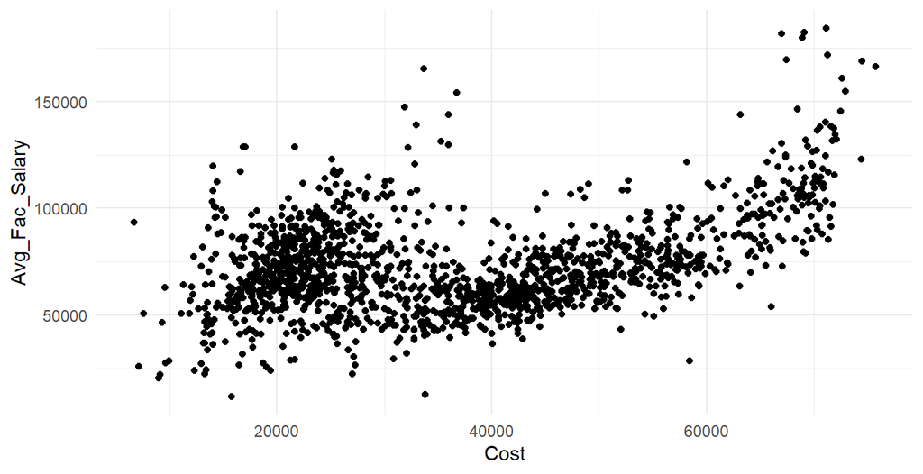

But once you consider whether the school is private or public you can see two distinct positive, linear relationships:

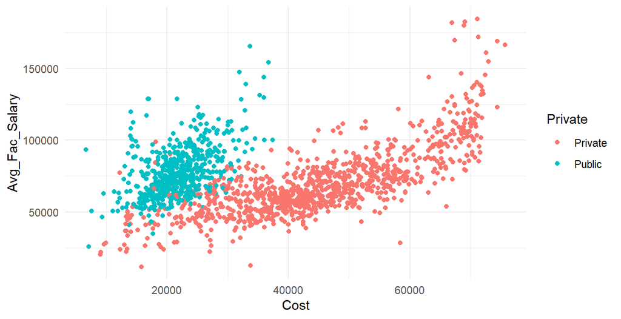

Additionally, if we suspect that other financial information, such as a school’s endowment, might be influencing this relationship since it is likely related to both variables.

For B, you should choose a single number (or small set of numbers that) accurately summarizes the relationship you’re looking at. Continuing the current example involving “Cost” and “Avg_Fac_Salary”, it’d be okay to report the correlation coefficient between these variables, but it’d be best to report the correlation coefficients for public and private school separately (ie: stratify the data) due to this being a confounding variable.

For review:

- When comparing *two categorical* variables, report an appropriate set of conditional proportions
- When comparing *two numeric* variables, report the correlation coefficient
- When comparing *one numeric* and *one categorical* variable, report an appropriate set of means/medians/standard deviations

*Note*: For categorical variables with many categories you aren’t expected to report on everything. For example, you might only report on OH vs. KY (or any pair of states that seems interesting) if you’re using the “State” variable.

**Question #9**: Using the variables you used in the Question #6, briefly respond to A) and B) listed above.

**Question #10**: Using the variables you used in the Question #7, briefly respond to A) and B) listed above.

**Question #11**: Using the variables you used in the Question #8, briefly respond to A) and B) listed above.

$~$

## Case Study #2 - Hollywood Movies

The [Hollywood Movies Dataset](https://remiller1450.github.io/data/HollywoodMovies.csv) contains information on 970 movies released by various Hollywood production studios between 2007 and 2013. It contains the following variables:

- **Movie**: Title of the movie
- **LeadStudio**: Studio that produced the movie
- **RottenTomatoes**: Rotten Tomatoes rating (from critics)
- **AudienceScore**: Rotten Tomatoes rating (from the audience)
- **Story**: Category of the movies general theme
- **Genre**: One of 14 possible genres
- **TheatersOpenWeek**: Number of theaters the movie was in screened in on opening weekend
- **OpeningWeekend**: Gross revenue on opening weekend
- **BOAverageOpenWeek**: Average box office income per theater on opening weekend
- **DomesticGross**: Gross income for domestic viewers (in millions)
- **ForeignGross**: Gross income for foreign viewers (in millions)
- **WorldGross**: Gross income for all viewers (in millions)
- **Budget**: Production budget (in millions)
- **Profitability**: WorldGross as a percentage of Budget
- **OpenProfit**: Percentage of budget earned on opening weekend
- **Year**: The year that the movie was released

### Exploration

**Question #12**: Describe the cases in this dataset. That is, what are they and how many are there?

On your own you should briefly explore the distributions of each variable, but I will not ask you to record anything for this in your answer document.

$~$

### Variable Combinations

**Question #13**: Identify at least one collection of variables that *would not* be very interesting to relate. Briefly explain why you feel it wouldn’t be very interesting to use these data to relate the variables you identified.

$~$

### Associations

**Question #14**: Identify two variables you believe to share an interesting relationship. For these variables report the following:

1. A visualization of the relationship
2. A summary measures that describes some aspect of the relationship
3. A statement regarding confounding variables (ie: can you think of any? are there any recorded in the data itself?)